# RED WINE QUALITY - FEATURE SELECTION FROM DATASET WITH R

# by Camila Santo

> This dataset with 1599 observations was publicly made available for research through the publication In Modeling wine preferences by data mining from physicochemical properties. In Decision Support Systems, Elsevier, 47(4):547-553. ISSN: 0167-9236. [Cortez et al., 2009]. It is a reference from two datasets, one using red and another white wine samples. The inputs included in both studies objective tests (e.g. PH values) and the output was based on sensory data (median of at least 3 evaluations made by wine experts). Each expert graded the wine quality from an option of 11 output attributes between 0 (very bad) and 10 (very excellent) based on an input of other 11 variables described below. The Number of Instances of red wine were 1599. Several data mining methods were applied to model this dataset under a regression approach. The support vector machine model apparently achieved the best results. Several metrics were computed: MAD, confusion matrix for a fixed error tolerance (T), etc. Also, creators plotted the relative importances of the input variables (as measured by a sensitivity analysis procedure).

> **Attributes information**

> **Input variables (based on physicochemical tests):** 1 - fixed acidity (tartaric acid - g / dm^3): most acids involved with wine or fixed or nonvolatile (do not evaporate readily) 2 - volatile acidity (acetic acid - g / dm^3): the amount of acetic acid in wine, which at too high of levels can lead to an unpleasant, vinegar taste 3 - citric acid (g / dm^3): found in small quantities, citric acid can add ‘freshness’ and flavor to wines 4 - residual sugar (g / dm^3): the amount of sugar remaining after fermentation stops, it’s rare to find wines with less than 1 gram/liter and wines with greater than 45 grams/liter are considered sweet 5 - chlorides (sodium chloride - g / dm^3): the amount of salt in the wine 6 - free sulfur dioxide (mg / dm^3): the free form of SO2 exists in equilibrium between molecular SO2 (as a dissolved gas) and bisulfite ion; it prevents microbial growth and the oxidation of wine 7 - total sulfur dioxide (mg / dm^3): amount of free and bound forms of S02; in low concentrations, SO2 is mostly undetectable in wine, but at free SO2 concentrations over 50 ppm, SO2 becomes evident in the nose and taste of wine 8 - density (g / cm^3): the density of water is close to that of water depending on the percent alcohol and sugar content 9 - pH: describes how acidic or basic a wine is on a scale from 0 (very acidic) to 14 (very basic); most wines are between 3-4 on the pH scale 10 - sulphates (potassium sulphate - g / dm3): a wine additive which can contribute to sulfur dioxide gas (S02) levels, wich acts as an antimicrobial and antioxidant 11 - alcohol (% by volume): the percent alcohol content of the wine

> **Output variable (based on sensory data):** 12 - quality (score between 0 and 10)

> **Missing values:** None

> Due to privacy and logistic issues, only physicochemical (inputs) and sensory (the output) variables are available (e.g. there is no data about grape types, wine brand, wine selling price, etc.). It was recommended to me that I viewed the dataset from classification or regression tasks, but highlighted that the classes were ordered and not balanced (there are munch more normal wines than excellent or poor ones according to instructions). Outlier detection algorithms were then recommended to detect the few excellent or poor wines. Even if all input variables were not considered surely relevant. For example, several of the attributes could be correlated to apply some sort of feature selection. So, finally, it is expected that I will test feature selection methods in this analysis.

```
## 'data.frame':    1599 obs. of  13 variables:
##  $ X                   : int  1 2 3 4 5 6 7 8 9 10 ...
##  $ fixed.acidity       : num  7.4 7.8 7.8 11.2 7.4 7.4 7.9 7.3 7.8 7.5 ...
##  $ volatile.acidity    : num  0.7 0.88 0.76 0.28 0.7 0.66 0.6 0.65 0.58 0.5 ...
##  $ citric.acid         : num  0 0 0.04 0.56 0 0 0.06 0 0.02 0.36 ...
##  $ residual.sugar      : num  1.9 2.6 2.3 1.9 1.9 1.8 1.6 1.2 2 6.1 ...
##  $ chlorides           : num  0.076 0.098 0.092 0.075 0.076 0.075 0.069 0.065 0.073 0.071 ...
##  $ free.sulfur.dioxide : num  11 25 15 17 11 13 15 15 9 17 ...
##  $ total.sulfur.dioxide: num  34 67 54 60 34 40 59 21 18 102 ...
##  $ density             : num  0.998 0.997 0.997 0.998 0.998 ...
##  $ pH                  : num  3.51 3.2 3.26 3.16 3.51 3.51 3.3 3.39 3.36 3.35 ...
##  $ sulphates           : num  0.56 0.68 0.65 0.58 0.56 0.56 0.46 0.47 0.57 0.8 ...
##  $ alcohol             : num  9.4 9.8 9.8 9.8 9.4 9.4 9.4 10 9.5 10.5 ...
##  $ quality             : int  5 5 5 6 5 5 5 7 7 5 ...
```

# Univariate Analysis

> **Finding the density of the standards**: Most of the evaluations were considered average with a mean of 5.636. This panorama doesn’t suggest outliers, but it’s a good start to define densities that might support a ranking, setting the least pleasant red wine options with evaluations ranging from 3-4 and the best between 7-8, in which 3 and 8 represent the extremes.

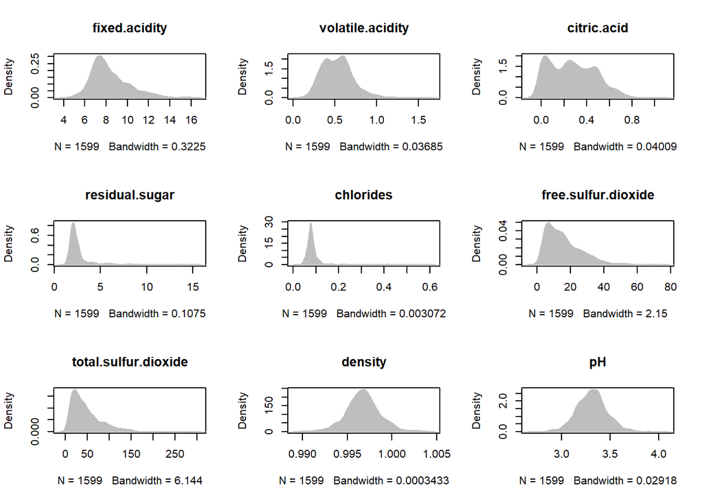

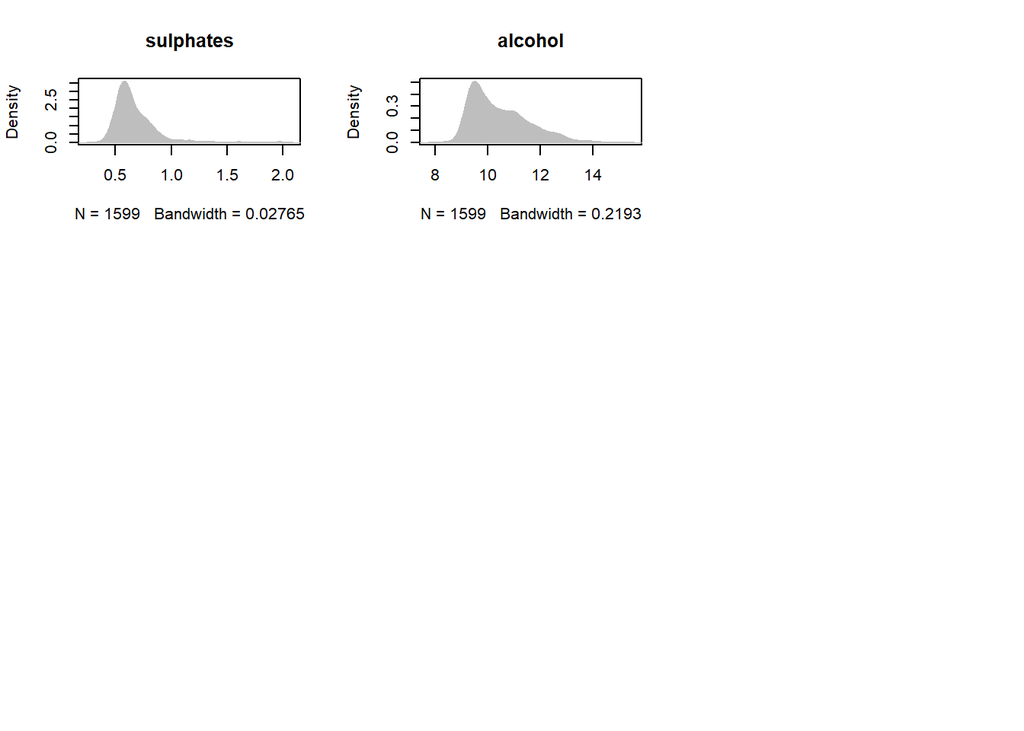

> **One feature influencing the quality evaluations**:

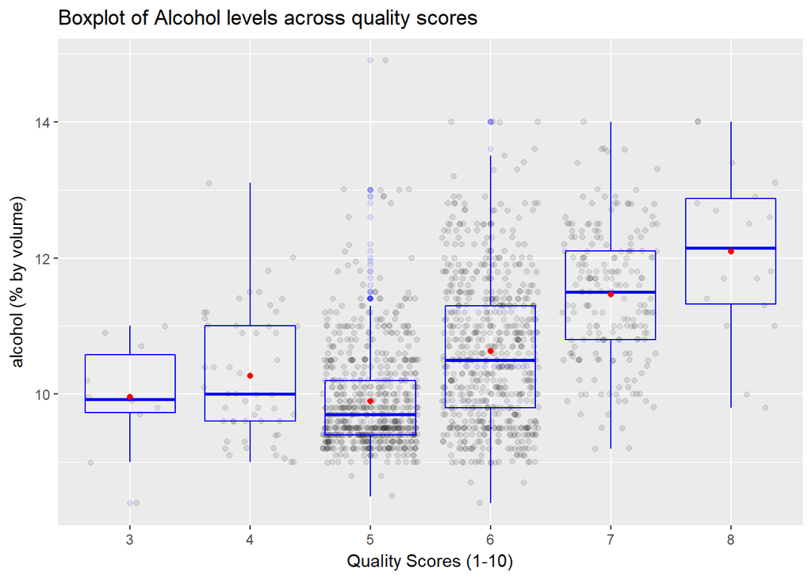

```
## mydata$alcohol: 8.4
##    Min. 1st Qu.  Median    Mean 3rd Qu.    Max.
##    3.00    3.75    4.50    4.50    5.25    6.00
## --------------------------------------------------------
## mydata$alcohol: 8.5
##    Min. 1st Qu.  Median    Mean 3rd Qu.    Max.
##       5       5       5       5       5       5
## --------------------------------------------------------
## mydata$alcohol: 8.7
##    Min. 1st Qu.  Median    Mean 3rd Qu.    Max.
##       6       6       6       6       6       6
## --------------------------------------------------------
## mydata$alcohol: 8.8
##    Min. 1st Qu.  Median    Mean 3rd Qu.    Max.
##       5       5       5       5       5       5
## --------------------------------------------------------
## mydata$alcohol: 9
##    Min. 1st Qu.  Median    Mean 3rd Qu.    Max.
##     3.0     5.0     6.0     5.4     6.0     6.0
## --------------------------------------------------------
## mydata$alcohol: 9.05
##    Min. 1st Qu.  Median    Mean 3rd Qu.    Max.
##       4       4       4       4       4       4
## --------------------------------------------------------
## mydata$alcohol: 9.1
##    Min. 1st Qu.  Median    Mean 3rd Qu.    Max.
##   4.000   5.000   5.000   5.217   6.000   6.000
## --------------------------------------------------------
## mydata$alcohol: 9.2
##    Min. 1st Qu.  Median    Mean 3rd Qu.    Max.
##    4.00    5.00    5.00    5.25    6.00    7.00
## --------------------------------------------------------
## mydata$alcohol: 9.23333333333333
##    Min. 1st Qu.  Median    Mean 3rd Qu.    Max.
##       6       6       6       6       6       6
## --------------------------------------------------------
## mydata$alcohol: 9.25
##    Min. 1st Qu.  Median    Mean 3rd Qu.    Max.
##       6       6       6       6       6       6
## --------------------------------------------------------
```

[output cut: 204 more lines]

```
## mydata$alcohol: 13.5666666666667
##    Min. 1st Qu.  Median    Mean 3rd Qu.    Max.
##       7       7       7       7       7       7
## --------------------------------------------------------
## mydata$alcohol: 13.6
##    Min. 1st Qu.  Median    Mean 3rd Qu.    Max.
##    6.00    6.75    7.00    6.75    7.00    7.00
## --------------------------------------------------------
## mydata$alcohol: 14
##    Min. 1st Qu.  Median    Mean 3rd Qu.    Max.
##   6.000   6.000   6.000   6.714   7.500   8.000
## --------------------------------------------------------
## mydata$alcohol: 14.9
##    Min. 1st Qu.  Median    Mean 3rd Qu.    Max.
##       5       5       5       5       5       5
```

> No new variable was created because the visualizations were sufficient to stimulate further investigation.

# Bivariate Plots

> **Looking for other features that might have influenced the quality evaluation**: After all, alcohol levels were not mentioned to be a relevant input, but seem to represent a factor at least influencing the highest ratings of sensory output. Based on the discoveries in the univariate plots, supported by the instructions for the analysis, relationships between quality and citric acid might be interesting to look at, because it seems to be considered a tasting feature of “freshness”, apparently a sign of red wine quality. The volatile acidity, on the other hand seem to be presented as an important factor for a red wine to be considered bad. These 2 types of variables allow to start looking for chemical factors that might also be associated with quality, even if their objetiveness might seem subjective, perhaps pointing reasons behind feature selection attributes. This way not limiting the relationships between the main output of quality with supporting variables. But looking at potential relationships between supporting variables as well, this analysis might identify differences between the objective interaction between some variables and the subjective output that their relationships might engage.

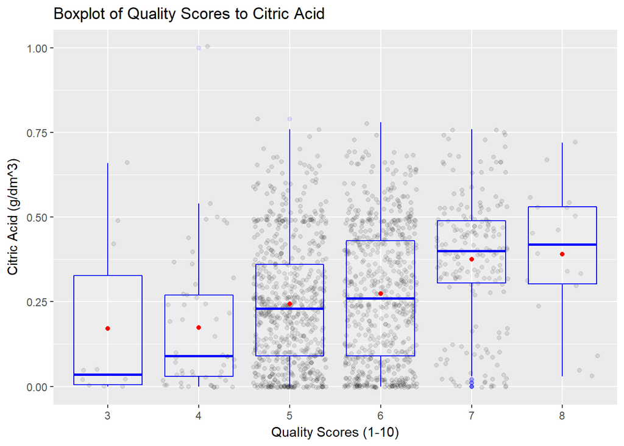

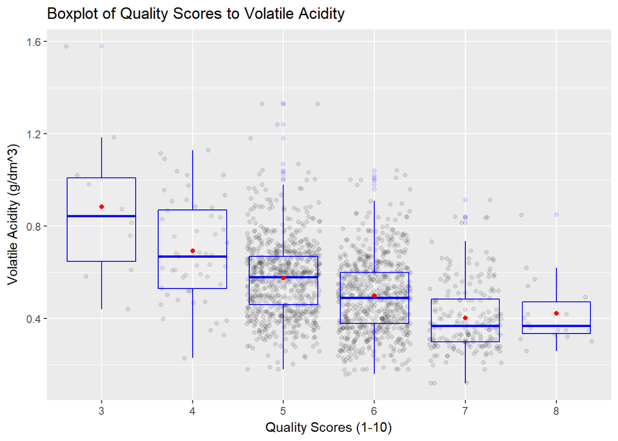

> The sulphates seem to be linked with the prevention of oxidation and microbial growth, that at the end is considered to be correlated with quality. But many features seem to correlate chemically in this matter, such as free and total sulfur dioxide. Other 2 variables the analysis must investigate to understand better what chemical features a good quality red wine must have, before we can dive into the influence of the sulphates feature for the selection of red wines.

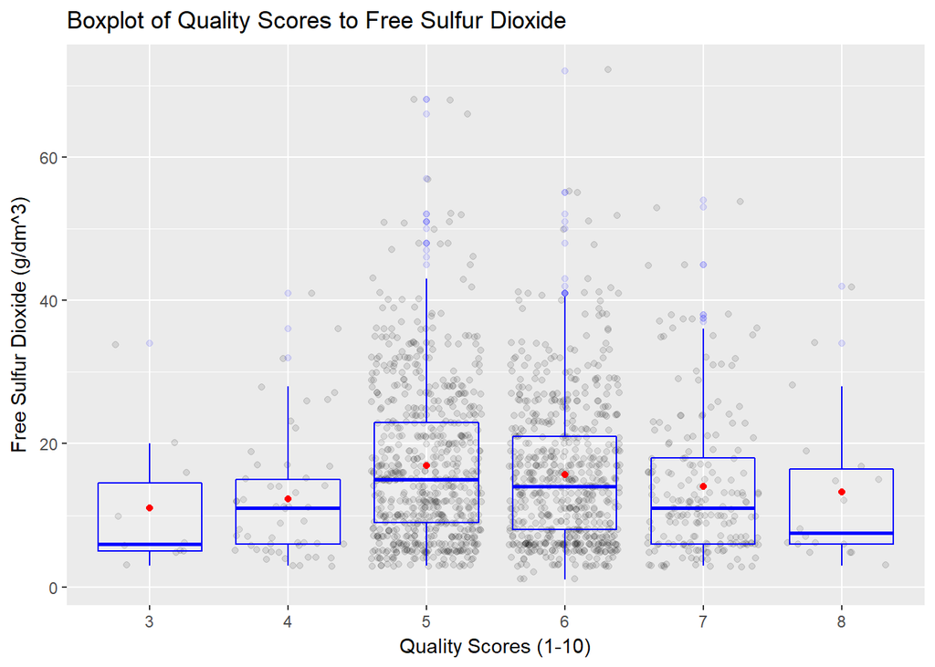

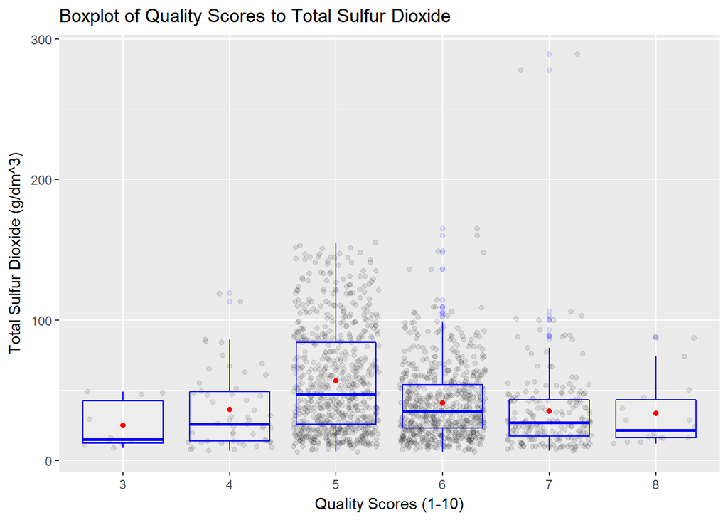

# Bivariate Analysis

```
##
##  Pearson's product-moment correlation
##
## data:  citric.acid and volatile.acidity
## t = -26.489, df = 1597, p-value < 2.2e-16
## alternative hypothesis: true correlation is not equal to 0
## 95 percent confidence interval:
##  -0.5856550 -0.5174902
## sample estimates:
##        cor
## -0.5524957
```

```
##
##  Pearson's product-moment correlation
##
## data:  free.sulfur.dioxide and total.sulfur.dioxide
## t = 35.84, df = 1597, p-value < 2.2e-16
## alternative hypothesis: true correlation is not equal to 0
## 95 percent confidence interval:
##  0.6395786 0.6939740
## sample estimates:
##       cor
## 0.6676665
```

# Multivariate Plots

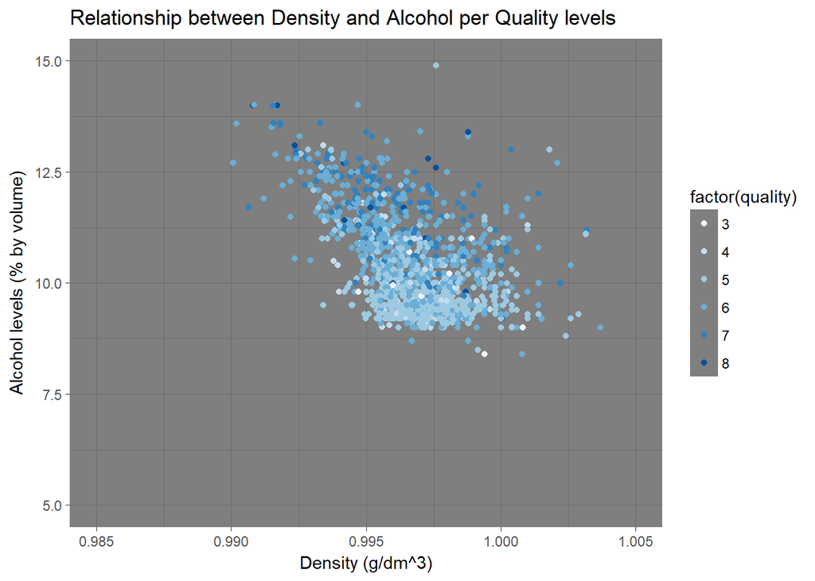

> **Looking for objective attribute relationships**: The bivariate plots seem to have elucidated more about the sensory experience of red wine tasting than providing good insights to establish a ranking of feature selection. We have already identified a relation between the percentage of alcohol and the quality evaluation in the univariate section, but it seems from the last plots, that there are chemical relations that also impact on the subjectiveness of the ratings. This analysis remains in need of onfirming objective input relationships that outcome in highest or lowest quality evaluations. The sulphates seem to be linked with the prevention of oxidation and microbial growth, that at the end is considered to be correlated with quality. So it’s time to try to understand that.

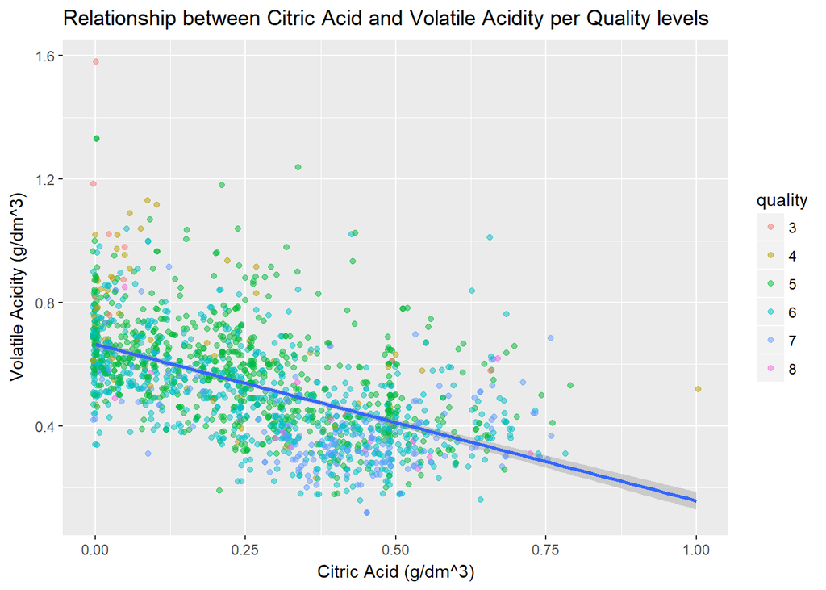

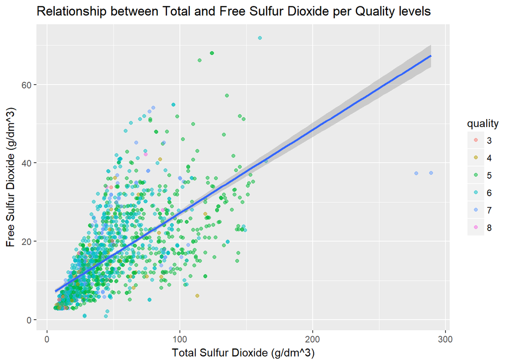

# Multivariate Analysis

> If we try to look at the multivariate relationship between sulphates, quality and alcohol from multiple angles, we end up finding a more evident relation when we visualize quality according to the percentage of alcohol within layers of quantity of sulphates. Clearly, lowest quality ratings below 5 are in majority for red wines with less than 12% alcohol and less than 0.57g/dm^3 of sulphates. While the highest quality ratings above 6 are in majority for red wines within the range of 10-14% alcohol and within the range of 0.79-1.2g/dm^3 of sulphates. Even if a strong correlation doesn’t seem evident (the linear regression seems pretty positively weak), it provides enough insight for this analysis to dive in this inquiry. We can finally come to an end with the inquiry about the impact of sulphates.

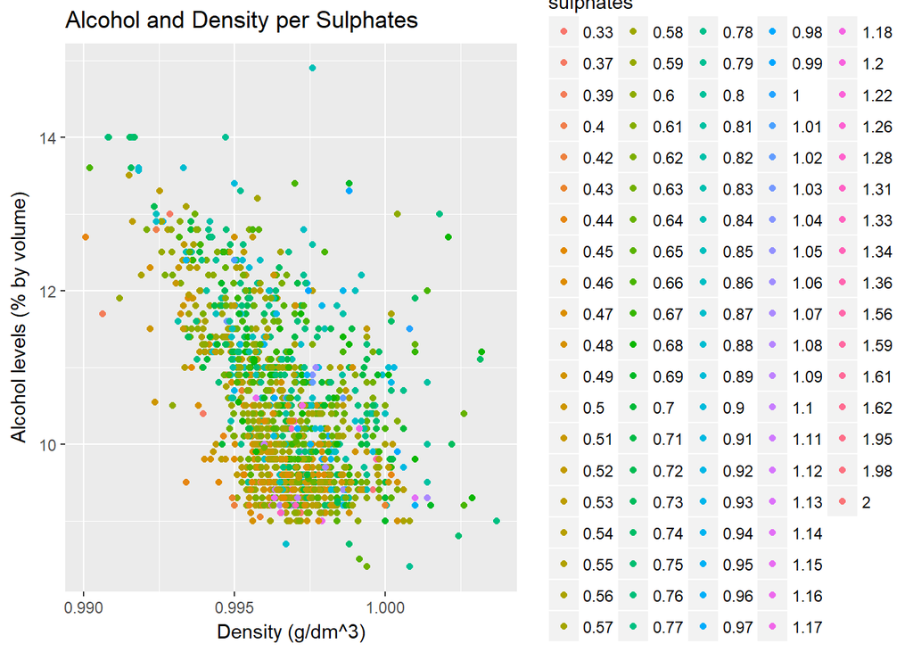

[figure not shown]

> From the previous section, we understood correlations between citric acid and volatile acidity, but didn’t complete crossing the relation with quality simultaneously. This more elaborated visualization confirms the previous ones and adds that the highest quality evaluations are situated where citric acid is of 0.5g/dm^3 and volatile acidity is at 0.4g/dm^3.

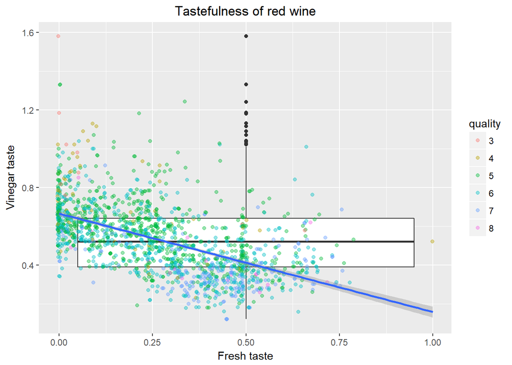

> When it comes to the relation between total sulfur dioxide, citric acid and alcohol, the most quality ratings are present when free sulfur dioxide is below 20mg/dm^3, and total sulfur dioxide is below 50mg/dm^3. But the best conclusion we may risk is that these two attributes should be as low as possible (within the parameters previously visualized from the previous plots) for the quality rating to increase.

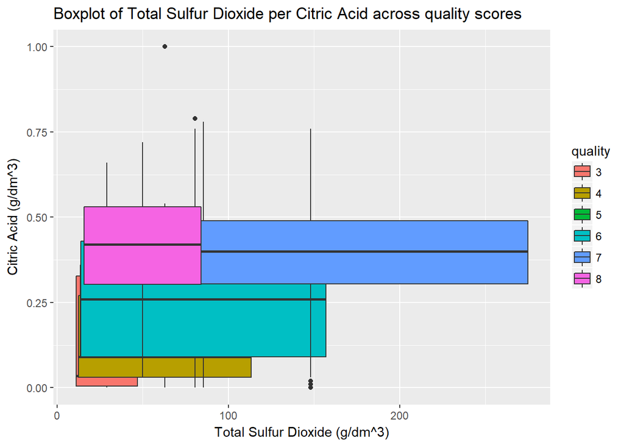

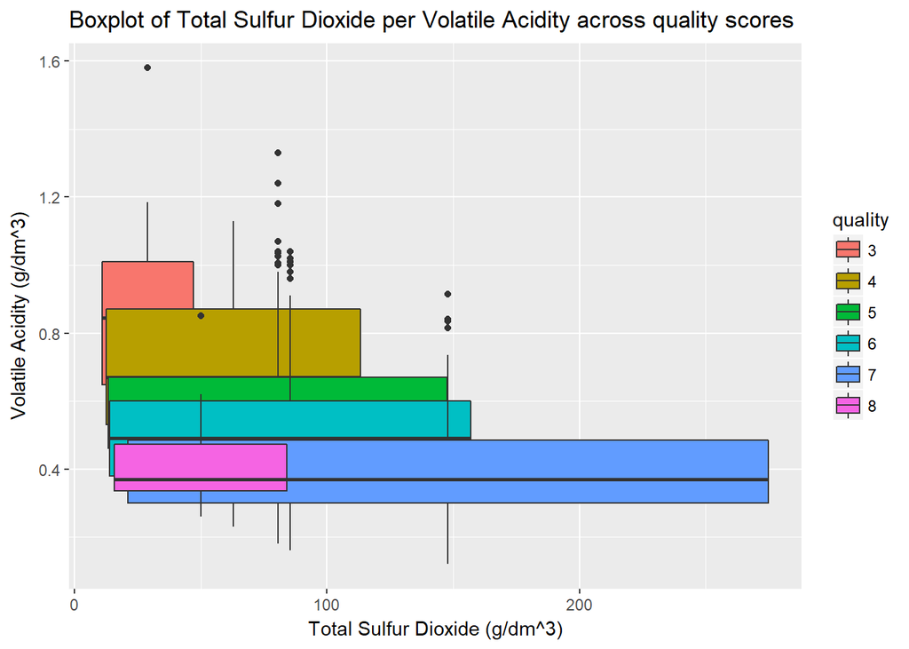

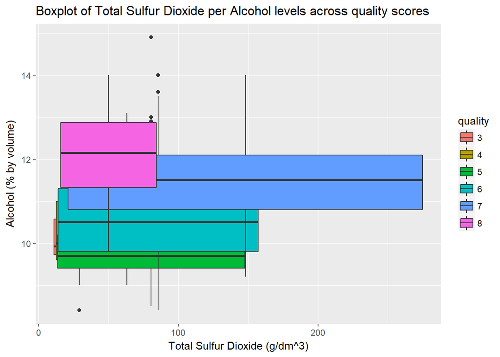

[figure not shown]

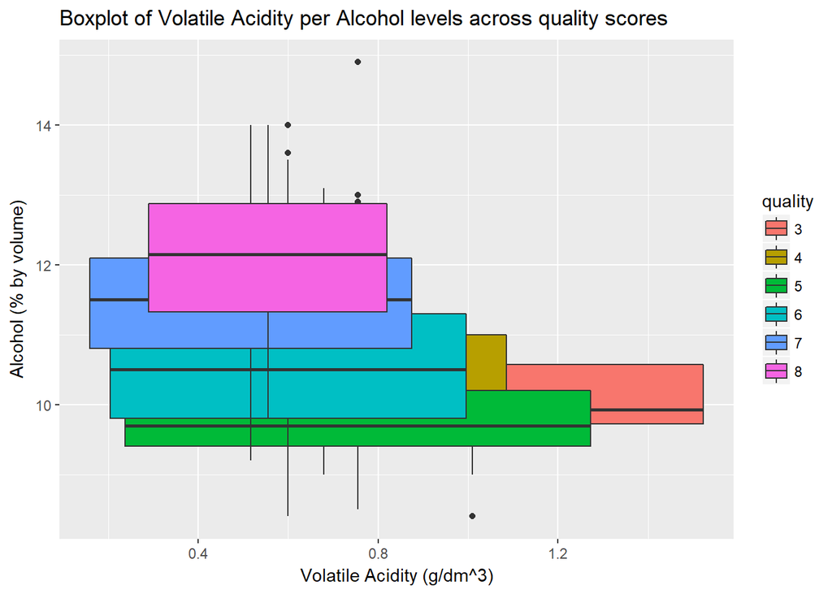

[figure not shown]

# Final Plots and Summary

> **Exploratory analysis conclusions**: The Red Wine Quality Dataset, as stated in the instructions, presented much more information than needed to fulfill the requests for investigating feature selection attributes. In answer to the requests, we can conclude after exploration of attributes and their mutual relationships: * The standards of red wine formulas are not as precise as they seem, and different types of correlations and regressions can be identified, filtering the attributes that have mostly affected the quality evaluation of the experts involved. These relationships are not situated in outliers as suggested, but become visible only when the right attributes are related. The instructions ended up being very helpful for tthe investigation. * The inputs that were not relevant for this specific analysis were the fixed acidity, residual sugar, chloride, and density. The relevance of the sulphates was minimal and only if correlated with several other attributes. Ph and free sulfur dioxide, relvealed not to be relevant factors for this analysis conclusions.

### Plot One

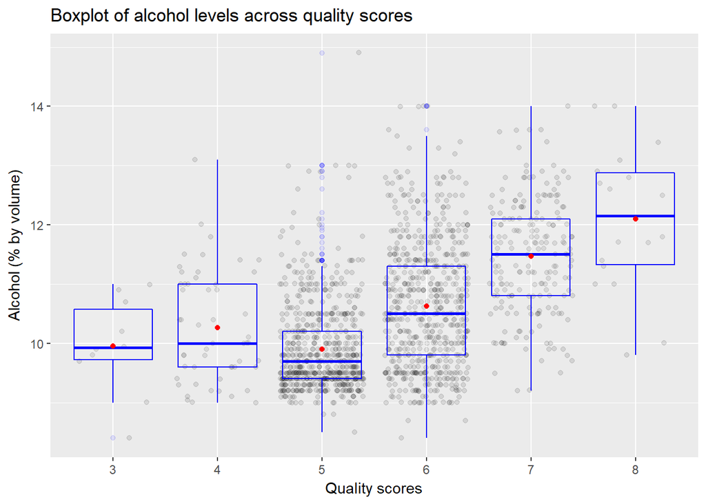

**First relevant reflection** > The percentage of alcohol seem to influence the sensory output, in a way that affect the tastefulness. While quality ratings where higher as percentages were higher, it is recommended for amateur customers to option for average percentages within the range of 10-14%, ideally around 12%.

### Plot Two

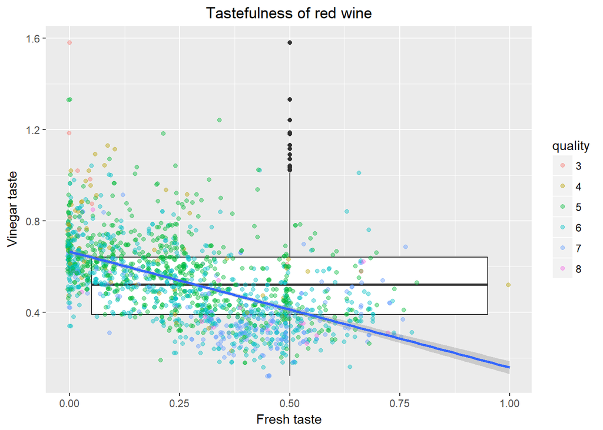

**Second relevant reflection** > The experience of drinking good quality red wine seem to be within a good proportion of freshness and vinegar tastes, and all the plots confirmed these amounts to be as low as possible for the vinegar taste and as average as posssible for the fresh taste.

### Plot Three

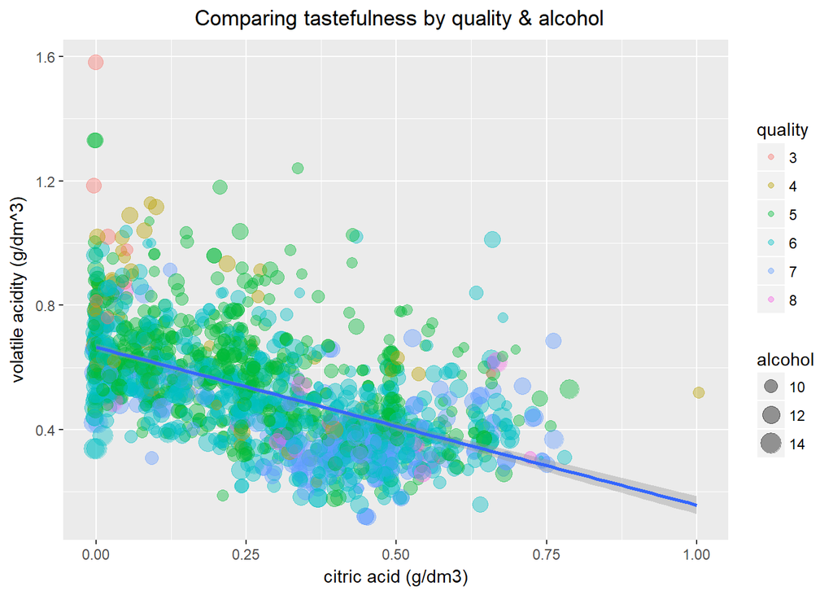

**Third relevant reflection** > The formula for the red wine feature selection seems to be a correlation between two attributes relationships, fresh and vinegar tastes (impacting negatively against each other), and percentage of alcohol correlated with quality evaluation.

# Final Reflection

> Sources: Dataset Created by Paulo Cortez (Univ. Minho), Antonio Cerdeira, Fernando Almeida, Telmo Matos and Jose Reis (CVRVV) @ 2009

> References: https://www.rstudio.com/resources/cheatsheets/ https://s3.amazonaws.com/udacity-hosted-downloads/ud651/correlation_images.jpeg http://blogs.acu.edu/jee99a/courses/quantitative-reasoning/linear-regression/ https://www.rstudio.com/resources/webinars/rstudio-essentials-webinar-series-managing-part-2/